# Risk Factor Analysis

## Outcome Variable

**Outcome Variable:** wasted

## Predictor Variables

**Intervention Variable:** meducyrs

**Adjustment Set:**

unadjusted

## Stratifying Variables

The analysis was stratified on these variable(s):

- agecat
- studyid
- country

## Data Summary

| agecat | studyid | country | meducyrs | wasted | n_cell | n |
| --- | --- | --- | --- | --- | --- | --- |
| Birth | ki0047075b-MAL-ED | BANGLADESH | Low | 0 | 54 | 195 |
| Birth | ki0047075b-MAL-ED | BANGLADESH | Low | 1 | 9 | 195 |
| Birth | ki0047075b-MAL-ED | BANGLADESH | Medium | 0 | 45 | 195 |
| Birth | ki0047075b-MAL-ED | BANGLADESH | Medium | 1 | 15 | 195 |
| Birth | ki0047075b-MAL-ED | BANGLADESH | High | 0 | 63 | 195 |
| Birth | ki0047075b-MAL-ED | BANGLADESH | High | 1 | 9 | 195 |
| Birth | ki0047075b-MAL-ED | BRAZIL | Low | 0 | 48 | 182 |
| Birth | ki0047075b-MAL-ED | BRAZIL | Low | 1 | 3 | 182 |
| Birth | ki0047075b-MAL-ED | BRAZIL | Medium | 0 | 65 | 182 |
| Birth | ki0047075b-MAL-ED | BRAZIL | Medium | 1 | 3 | 182 |
| Birth | ki0047075b-MAL-ED | BRAZIL | High | 0 | 63 | 182 |
| Birth | ki0047075b-MAL-ED | BRAZIL | High | 1 | 0 | 182 |
| Birth | ki0047075b-MAL-ED | INDIA | Low | 0 | 48 | 180 |
| Birth | ki0047075b-MAL-ED | INDIA | Low | 1 | 12 | 180 |
| Birth | ki0047075b-MAL-ED | INDIA | Medium | 0 | 55 | 180 |
| Birth | ki0047075b-MAL-ED | INDIA | Medium | 1 | 14 | 180 |
| Birth | ki0047075b-MAL-ED | INDIA | High | 0 | 47 | 180 |
| Birth | ki0047075b-MAL-ED | INDIA | High | 1 | 4 | 180 |
| Birth | ki0047075b-MAL-ED | NEPAL | Low | 0 | 61 | 155 |
| Birth | ki0047075b-MAL-ED | NEPAL | Low | 1 | 4 | 155 |
| Birth | ki0047075b-MAL-ED | NEPAL | Medium | 0 | 45 | 155 |
| Birth | ki0047075b-MAL-ED | NEPAL | Medium | 1 | 8 | 155 |
| Birth | ki0047075b-MAL-ED | NEPAL | High | 0 | 30 | 155 |
| Birth | ki0047075b-MAL-ED | NEPAL | High | 1 | 7 | 155 |
| Birth | ki0047075b-MAL-ED | PERU | Low | 0 | 98 | 278 |
| Birth | ki0047075b-MAL-ED | PERU | Low | 1 | 0 | 278 |
| Birth | ki0047075b-MAL-ED | PERU | Medium | 0 | 94 | 278 |
| Birth | ki0047075b-MAL-ED | PERU | Medium | 1 | 4 | 278 |
| Birth | ki0047075b-MAL-ED | PERU | High | 0 | 80 | 278 |
| Birth | ki0047075b-MAL-ED | PERU | High | 1 | 2 | 278 |

[output cut: 378 more lines]

The following strata were considered:

- agecat: 24 months, studyid: ki0047075b-MAL-ED, country: BANGLADESH
- agecat: 24 months, studyid: ki0047075b-MAL-ED, country: BRAZIL
- agecat: 24 months, studyid: ki0047075b-MAL-ED, country: INDIA
- agecat: 24 months, studyid: ki0047075b-MAL-ED, country: NEPAL
- agecat: 24 months, studyid: ki0047075b-MAL-ED, country: PERU
- agecat: 24 months, studyid: ki0047075b-MAL-ED, country: SOUTH AFRICA
- agecat: 24 months, studyid: ki0047075b-MAL-ED, country: TANZANIA, UNITED REPUBLIC OF
- agecat: 24 months, studyid: ki1000108-CMC-V-BCS-2002, country: INDIA
- agecat: 24 months, studyid: ki1000108-IRC, country: INDIA
- agecat: 24 months, studyid: ki1017093-NIH-Birth, country: BANGLADESH
- agecat: 24 months, studyid: ki1017093b-PROVIDE, country: BANGLADESH
- agecat: 24 months, studyid: ki1017093c-NIH-Crypto, country: BANGLADESH
- agecat: 24 months, studyid: ki1066203-TanzaniaChild2, country: TANZANIA, UNITED REPUBLIC OF
- agecat: 24 months, studyid: ki1113344-GMS-Nepal, country: NEPAL
- agecat: 24 months, studyid: ki1119695-PROBIT, country: BELARUS
- agecat: 24 months, studyid: ki1126311-ZVITAMBO, country: ZIMBABWE
- agecat: 24 months, studyid: ki1135781-COHORTS, country: GUATEMALA
- agecat: 24 months, studyid: ki1135781-COHORTS, country: INDIA
- agecat: 24 months, studyid: ki1135781-COHORTS, country: PHILIPPINES
- agecat: 24 months, studyid: ki1148112-LCNI-5, country: MALAWI
- agecat: 24 months, studyid: kiGH5241-JiVitA-3, country: BANGLADESH
- agecat: 24 months, studyid: kiGH5241-JiVitA-4, country: BANGLADESH
- agecat: 6 months, studyid: ki0047075b-MAL-ED, country: BANGLADESH
- agecat: 6 months, studyid: ki0047075b-MAL-ED, country: BRAZIL
- agecat: 6 months, studyid: ki0047075b-MAL-ED, country: INDIA
- agecat: 6 months, studyid: ki0047075b-MAL-ED, country: NEPAL
- agecat: 6 months, studyid: ki0047075b-MAL-ED, country: PERU
- agecat: 6 months, studyid: ki0047075b-MAL-ED, country: SOUTH AFRICA
- agecat: 6 months, studyid: ki0047075b-MAL-ED, country: TANZANIA, UNITED REPUBLIC OF
- agecat: 6 months, studyid: ki1000108-CMC-V-BCS-2002, country: INDIA
- agecat: 6 months, studyid: ki1000108-IRC, country: INDIA
- agecat: 6 months, studyid: ki1000109-EE, country: PAKISTAN
- agecat: 6 months, studyid: ki1000304b-SAS-CompFeed, country: INDIA
- agecat: 6 months, studyid: ki1000304b-SAS-FoodSuppl, country: INDIA
- agecat: 6 months, studyid: ki1017093-NIH-Birth, country: BANGLADESH
- agecat: 6 months, studyid: ki1017093b-PROVIDE, country: BANGLADESH
- agecat: 6 months, studyid: ki1017093c-NIH-Crypto, country: BANGLADESH
- agecat: 6 months, studyid: ki1066203-TanzaniaChild2, country: TANZANIA, UNITED REPUBLIC OF
- agecat: 6 months, studyid: ki1112895-Guatemala BSC, country: GUATEMALA
- agecat: 6 months, studyid: ki1113344-GMS-Nepal, country: NEPAL
- agecat: 6 months, studyid: ki1119695-PROBIT, country: BELARUS
- agecat: 6 months, studyid: ki1126311-ZVITAMBO, country: ZIMBABWE
- agecat: 6 months, studyid: ki1135781-COHORTS, country: GUATEMALA
- agecat: 6 months, studyid: ki1135781-COHORTS, country: INDIA
- agecat: 6 months, studyid: ki1135781-COHORTS, country: PHILIPPINES
- agecat: 6 months, studyid: ki1148112-LCNI-5, country: MALAWI
- agecat: 6 months, studyid: kiGH5241-JiVitA-3, country: BANGLADESH
- agecat: 6 months, studyid: kiGH5241-JiVitA-4, country: BANGLADESH
- agecat: Birth, studyid: ki0047075b-MAL-ED, country: BANGLADESH
- agecat: Birth, studyid: ki0047075b-MAL-ED, country: BRAZIL
- agecat: Birth, studyid: ki0047075b-MAL-ED, country: INDIA
- agecat: Birth, studyid: ki0047075b-MAL-ED, country: NEPAL
- agecat: Birth, studyid: ki0047075b-MAL-ED, country: PERU
- agecat: Birth, studyid: ki0047075b-MAL-ED, country: SOUTH AFRICA
- agecat: Birth, studyid: ki0047075b-MAL-ED, country: TANZANIA, UNITED REPUBLIC OF
- agecat: Birth, studyid: ki1000108-CMC-V-BCS-2002, country: INDIA
- agecat: Birth, studyid: ki1000108-IRC, country: INDIA
- agecat: Birth, studyid: ki1000109-EE, country: PAKISTAN
- agecat: Birth, studyid: ki1000304b-SAS-CompFeed, country: INDIA
- agecat: Birth, studyid: ki1017093-NIH-Birth, country: BANGLADESH
- agecat: Birth, studyid: ki1017093c-NIH-Crypto, country: BANGLADESH
- agecat: Birth, studyid: ki1119695-PROBIT, country: BELARUS
- agecat: Birth, studyid: ki1126311-ZVITAMBO, country: ZIMBABWE
- agecat: Birth, studyid: ki1135781-COHORTS, country: GUATEMALA
- agecat: Birth, studyid: ki1135781-COHORTS, country: INDIA
- agecat: Birth, studyid: ki1135781-COHORTS, country: PHILIPPINES
- agecat: Birth, studyid: kiGH5241-JiVitA-3, country: BANGLADESH
- agecat: Birth, studyid: kiGH5241-JiVitA-4, country: BANGLADESH

### Dropped Strata

Some strata were dropped due to rare outcomes:

- agecat: Birth, studyid: ki0047075b-MAL-ED, country: BRAZIL
- agecat: Birth, studyid: ki0047075b-MAL-ED, country: INDIA
- agecat: Birth, studyid: ki0047075b-MAL-ED, country: NEPAL
- agecat: Birth, studyid: ki0047075b-MAL-ED, country: PERU
- agecat: Birth, studyid: ki0047075b-MAL-ED, country: SOUTH AFRICA
- agecat: Birth, studyid: ki0047075b-MAL-ED, country: TANZANIA, UNITED REPUBLIC OF
- agecat: Birth, studyid: ki1000108-CMC-V-BCS-2002, country: INDIA
- agecat: Birth, studyid: ki1000109-EE, country: PAKISTAN
- agecat: Birth, studyid: ki1000304b-SAS-CompFeed, country: INDIA
- agecat: Birth, studyid: ki1017093-NIH-Birth, country: BANGLADESH
- agecat: Birth, studyid: ki1017093c-NIH-Crypto, country: BANGLADESH
- agecat: Birth, studyid: kiGH5241-JiVitA-4, country: BANGLADESH
- agecat: 6 months, studyid: ki0047075b-MAL-ED, country: BANGLADESH
- agecat: 6 months, studyid: ki0047075b-MAL-ED, country: BRAZIL
- agecat: 6 months, studyid: ki0047075b-MAL-ED, country: NEPAL
- agecat: 6 months, studyid: ki0047075b-MAL-ED, country: PERU
- agecat: 6 months, studyid: ki0047075b-MAL-ED, country: SOUTH AFRICA
- agecat: 6 months, studyid: ki0047075b-MAL-ED, country: TANZANIA, UNITED REPUBLIC OF
- agecat: 6 months, studyid: ki1000109-EE, country: PAKISTAN
- agecat: 6 months, studyid: ki1000304b-SAS-FoodSuppl, country: INDIA
- agecat: 6 months, studyid: ki1017093c-NIH-Crypto, country: BANGLADESH
- agecat: 6 months, studyid: ki1066203-TanzaniaChild2, country: TANZANIA, UNITED REPUBLIC OF
- agecat: 6 months, studyid: ki1112895-Guatemala BSC, country: GUATEMALA
- agecat: 6 months, studyid: ki1113344-GMS-Nepal, country: NEPAL
- agecat: 6 months, studyid: ki1148112-LCNI-5, country: MALAWI
- agecat: 6 months, studyid: kiGH5241-JiVitA-4, country: BANGLADESH
- agecat: 24 months, studyid: ki0047075b-MAL-ED, country: BANGLADESH
- agecat: 24 months, studyid: ki0047075b-MAL-ED, country: BRAZIL
- agecat: 24 months, studyid: ki0047075b-MAL-ED, country: INDIA
- agecat: 24 months, studyid: ki0047075b-MAL-ED, country: NEPAL
- agecat: 24 months, studyid: ki0047075b-MAL-ED, country: PERU
- agecat: 24 months, studyid: ki0047075b-MAL-ED, country: SOUTH AFRICA
- agecat: 24 months, studyid: ki0047075b-MAL-ED, country: TANZANIA, UNITED REPUBLIC OF
- agecat: 24 months, studyid: ki1066203-TanzaniaChild2, country: TANZANIA, UNITED REPUBLIC OF
- agecat: 24 months, studyid: ki1148112-LCNI-5, country: MALAWI

## Methods Detail

We’re interested in the causal parameters $E[Y_a]$ for all values of $a \in \mathcal{A}$. These parameters represent the mean outcome if, possibly contrary to fact, we intervened to set all units to have $A=a$. Under the randomization and positivity assumptions, these are identified by the statistical parameters $\psi_a=E_W[E_{Y|A,W}(Y|A=a,W)]$. In addition, we’re interested in the mean of $Y$, $E[Y]$ under no intervention (the observed mean). We will estimate these parameters by using SuperLearner to fit the relevant likelihood factors – $E_{Y|A,W}(Y|A=a,W)$ and $p(A=a|W)$, and then updating our likelihood fit using a joint TMLE.

For unadjusted analyses ($W=\{\}$), initial likelihoods were estimated using Lrnr_glm to estimate the simple $E(Y|A)$ and Lrnr_mean to estimate $p(A)$. For adjusted analyses, a small library containing Lrnr_glmnet, Lrnr_xgboost, and Lrnr_mean was used.

Having estimated these parameters, we will then use the delta method to estimate relative risks and attributable risks relative to a prespecified baseline level of $A$.

# Results Detail

## Results Plots

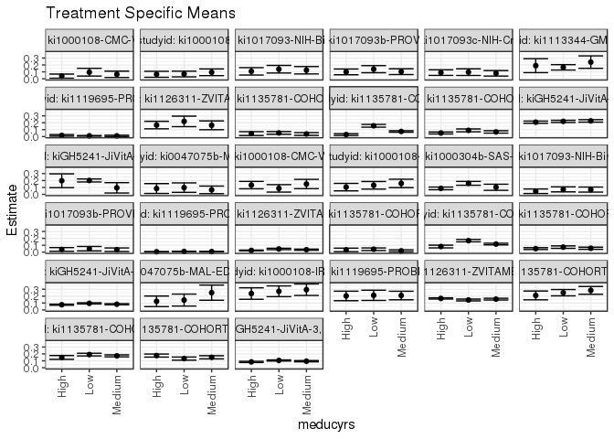

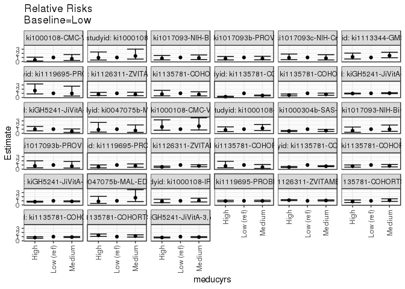

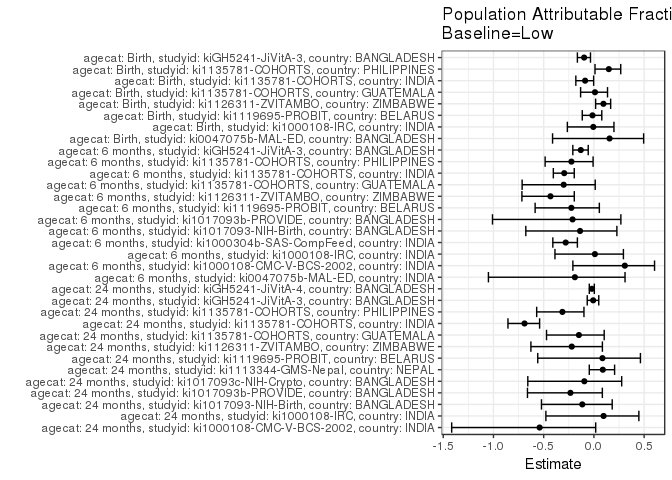

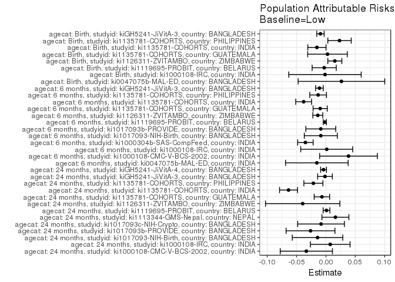

## Results Table

### Parameter: TSM

| agecat | studyid | country | intervention_level | baseline_level | estimate | ci_lower | ci_upper |
| --- | --- | --- | --- | --- | --- | --- | --- |
| Birth | ki0047075b-MAL-ED | BANGLADESH | Low | NA | 0.1428571 | 0.0562264 | 0.2294878 |
| Birth | ki0047075b-MAL-ED | BANGLADESH | Medium | NA | 0.2500000 | 0.1401527 | 0.3598473 |
| Birth | ki0047075b-MAL-ED | BANGLADESH | High | NA | 0.1250000 | 0.0484126 | 0.2015874 |
| Birth | ki1000108-IRC | INDIA | Low | NA | 0.2698413 | 0.1922238 | 0.3474588 |
| Birth | ki1000108-IRC | INDIA | Medium | NA | 0.2931034 | 0.2101487 | 0.3760582 |
| Birth | ki1000108-IRC | INDIA | High | NA | 0.2376238 | 0.1544951 | 0.3207525 |
| Birth | ki1119695-PROBIT | BELARUS | Low | NA | 0.2118575 | 0.1375876 | 0.2861275 |
| Birth | ki1119695-PROBIT | BELARUS | Medium | NA | 0.2088226 | 0.1467503 | 0.2708950 |
| Birth | ki1119695-PROBIT | BELARUS | High | NA | 0.2026786 | 0.1337768 | 0.2715803 |
| Birth | ki1126311-ZVITAMBO | ZIMBABWE | Low | NA | 0.1442878 | 0.1310236 | 0.1575521 |
| Birth | ki1126311-ZVITAMBO | ZIMBABWE | Medium | NA | 0.1566719 | 0.1440477 | 0.1692961 |
| Birth | ki1126311-ZVITAMBO | ZIMBABWE | High | NA | 0.1665004 | 0.1577825 | 0.1752182 |
| Birth | ki1135781-COHORTS | GUATEMALA | Low | NA | 0.2500000 | 0.2042111 | 0.2957889 |
| Birth | ki1135781-COHORTS | GUATEMALA | Medium | NA | 0.2834008 | 0.2271629 | 0.3396387 |
| Birth | ki1135781-COHORTS | GUATEMALA | High | NA | 0.2101911 | 0.1464151 | 0.2739670 |
| Birth | ki1135781-COHORTS | INDIA | Low | NA | 0.1903870 | 0.1711597 | 0.2096143 |
| Birth | ki1135781-COHORTS | INDIA | Medium | NA | 0.1720717 | 0.1576203 | 0.1865231 |
| Birth | ki1135781-COHORTS | INDIA | High | NA | 0.1493902 | 0.1221088 | 0.1766717 |
| Birth | ki1135781-COHORTS | PHILIPPINES | Low | NA | 0.1324582 | 0.1095028 | 0.1554137 |
| Birth | ki1135781-COHORTS | PHILIPPINES | Medium | NA | 0.1511254 | 0.1281389 | 0.1741119 |
| Birth | ki1135781-COHORTS | PHILIPPINES | High | NA | 0.1764184 | 0.1541703 | 0.1986666 |
| Birth | kiGH5241-JiVitA-3 | BANGLADESH | Low | NA | 0.1053649 | 0.0968852 | 0.1138447 |
| Birth | kiGH5241-JiVitA-3 | BANGLADESH | Medium | NA | 0.0948240 | 0.0860181 | 0.1036299 |
| Birth | kiGH5241-JiVitA-3 | BANGLADESH | High | NA | 0.0847676 | 0.0760571 | 0.0934782 |
| 6 months | ki0047075b-MAL-ED | INDIA | Low | NA | 0.0972222 | 0.0286258 | 0.1658187 |
| 6 months | ki0047075b-MAL-ED | INDIA | Medium | NA | 0.0649351 | 0.0097642 | 0.1201059 |
| 6 months | ki0047075b-MAL-ED | INDIA | High | NA | 0.0847458 | 0.0135099 | 0.1559816 |
| 6 months | ki1000108-CMC-V-BCS-2002 | INDIA | Low | NA | 0.0865385 | 0.0324291 | 0.1406478 |
| 6 months | ki1000108-CMC-V-BCS-2002 | INDIA | Medium | NA | 0.1495327 | 0.0818708 | 0.2171946 |
| 6 months | ki1000108-CMC-V-BCS-2002 | INDIA | High | NA | 0.1337580 | 0.0804406 | 0.1870753 |

[output cut: 69 more lines]

### Parameter: E(Y)

| agecat | studyid | country | intervention_level | baseline_level | estimate | ci_lower | ci_upper |
| --- | --- | --- | --- | --- | --- | --- | --- |
| Birth | ki0047075b-MAL-ED | BANGLADESH | NA | NA | 0.1692308 | 0.1164681 | 0.2219935 |
| Birth | ki1000108-IRC | INDIA | NA | NA | 0.2682216 | 0.2212677 | 0.3151755 |
| Birth | ki1119695-PROBIT | BELARUS | NA | NA | 0.2089120 | 0.1435514 | 0.2742726 |
| Birth | ki1126311-ZVITAMBO | ZIMBABWE | NA | NA | 0.1594293 | 0.1531109 | 0.1657477 |
| Birth | ki1135781-COHORTS | GUATEMALA | NA | NA | 0.2526738 | 0.2215120 | 0.2838356 |
| Birth | ki1135781-COHORTS | INDIA | NA | NA | 0.1750359 | 0.1643722 | 0.1856996 |
| Birth | ki1135781-COHORTS | PHILIPPINES | NA | NA | 0.1555709 | 0.1423748 | 0.1687670 |
| Birth | kiGH5241-JiVitA-3 | BANGLADESH | NA | NA | 0.0960153 | 0.0908094 | 0.1012212 |
| 6 months | ki0047075b-MAL-ED | INDIA | NA | NA | 0.0817308 | 0.0444108 | 0.1190507 |
| 6 months | ki1000108-CMC-V-BCS-2002 | INDIA | NA | NA | 0.1250000 | 0.0911644 | 0.1588356 |
| 6 months | ki1000108-IRC | INDIA | NA | NA | 0.1323529 | 0.0994307 | 0.1652752 |
| 6 months | ki1000304b-SAS-CompFeed | INDIA | NA | NA | 0.1244378 | 0.0992652 | 0.1496104 |
| 6 months | ki1017093-NIH-Birth | BANGLADESH | NA | NA | 0.0634328 | 0.0427791 | 0.0840865 |
| 6 months | ki1017093b-PROVIDE | BANGLADESH | NA | NA | 0.0412371 | 0.0250690 | 0.0574052 |
| 6 months | ki1119695-PROBIT | BELARUS | NA | NA | 0.0082503 | 0.0066012 | 0.0098994 |
| 6 months | ki1126311-ZVITAMBO | ZIMBABWE | NA | NA | 0.0321173 | 0.0283128 | 0.0359219 |
| 6 months | ki1135781-COHORTS | GUATEMALA | NA | NA | 0.0325289 | 0.0212599 | 0.0437978 |
| 6 months | ki1135781-COHORTS | INDIA | NA | NA | 0.1283521 | 0.1194359 | 0.1372684 |
| 6 months | ki1135781-COHORTS | PHILIPPINES | NA | NA | 0.0594974 | 0.0505830 | 0.0684118 |
| 6 months | kiGH5241-JiVitA-3 | BANGLADESH | NA | NA | 0.0846305 | 0.0798233 | 0.0894378 |
| 24 months | ki1000108-CMC-V-BCS-2002 | INDIA | NA | NA | 0.0618280 | 0.0373207 | 0.0863352 |
| 24 months | ki1000108-IRC | INDIA | NA | NA | 0.0757946 | 0.0501131 | 0.1014762 |
| 24 months | ki1017093-NIH-Birth | BANGLADESH | NA | NA | 0.1238318 | 0.0925894 | 0.1550741 |
| 24 months | ki1017093b-PROVIDE | BANGLADESH | NA | NA | 0.1124567 | 0.0866788 | 0.1382347 |
| 24 months | ki1017093c-NIH-Crypto | BANGLADESH | NA | NA | 0.0875486 | 0.0630907 | 0.1120065 |
| 24 months | ki1113344-GMS-Nepal | NEPAL | NA | NA | 0.1818182 | 0.1478065 | 0.2158299 |
| 24 months | ki1119695-PROBIT | BELARUS | NA | NA | 0.0110803 | 0.0050506 | 0.0171100 |
| 24 months | ki1126311-ZVITAMBO | ZIMBABWE | NA | NA | 0.1796690 | 0.1430402 | 0.2162979 |
| 24 months | ki1135781-COHORTS | GUATEMALA | NA | NA | 0.0458801 | 0.0333262 | 0.0584341 |
| 24 months | ki1135781-COHORTS | INDIA | NA | NA | 0.0921747 | 0.0833896 | 0.1009599 |
| 24 months | ki1135781-COHORTS | PHILIPPINES | NA | NA | 0.0681911 | 0.0582056 | 0.0781766 |
| 24 months | kiGH5241-JiVitA-3 | BANGLADESH | NA | NA | 0.2181099 | 0.2082292 | 0.2279905 |
| 24 months | kiGH5241-JiVitA-4 | BANGLADESH | NA | NA | 0.1970000 | 0.1761171 | 0.2178829 |

### Parameter: RR

| agecat | studyid | country | intervention_level | baseline_level | estimate | ci_lower | ci_upper |
| --- | --- | --- | --- | --- | --- | --- | --- |
| Birth | ki0047075b-MAL-ED | BANGLADESH | Low | Low | 1.0000000 | 1.0000000 | 1.0000000 |
| Birth | ki0047075b-MAL-ED | BANGLADESH | Medium | Low | 1.7500000 | 0.8275784 | 3.7005556 |
| Birth | ki0047075b-MAL-ED | BANGLADESH | High | Low | 0.8750000 | 0.3695066 | 2.0720199 |
| Birth | ki1000108-IRC | INDIA | Low | Low | 1.0000000 | 1.0000000 | 1.0000000 |
| Birth | ki1000108-IRC | INDIA | Medium | Low | 1.0862069 | 0.7255382 | 1.6261659 |
| Birth | ki1000108-IRC | INDIA | High | Low | 0.8806057 | 0.5598715 | 1.3850793 |
| Birth | ki1119695-PROBIT | BELARUS | Low | Low | 1.0000000 | 1.0000000 | 1.0000000 |
| Birth | ki1119695-PROBIT | BELARUS | Medium | Low | 0.9856748 | 0.8445793 | 1.1503416 |
| Birth | ki1119695-PROBIT | BELARUS | High | Low | 0.9566738 | 0.7987550 | 1.1458143 |
| Birth | ki1126311-ZVITAMBO | ZIMBABWE | Low | Low | 1.0000000 | 1.0000000 | 1.0000000 |
| Birth | ki1126311-ZVITAMBO | ZIMBABWE | Medium | Low | 1.0858289 | 0.9608848 | 1.2270196 |
| Birth | ki1126311-ZVITAMBO | ZIMBABWE | High | Low | 1.1539459 | 1.0381005 | 1.2827190 |
| Birth | ki1135781-COHORTS | GUATEMALA | Low | Low | 1.0000000 | 1.0000000 | 1.0000000 |
| Birth | ki1135781-COHORTS | GUATEMALA | Medium | Low | 1.1336032 | 0.8653308 | 1.4850462 |
| Birth | ki1135781-COHORTS | GUATEMALA | High | Low | 0.8407643 | 0.5898674 | 1.1983788 |
| Birth | ki1135781-COHORTS | INDIA | Low | Low | 1.0000000 | 1.0000000 | 1.0000000 |
| Birth | ki1135781-COHORTS | INDIA | Medium | Low | 0.9037997 | 0.7925525 | 1.0306622 |
| Birth | ki1135781-COHORTS | INDIA | High | Low | 0.7846661 | 0.6368762 | 0.9667514 |
| Birth | ki1135781-COHORTS | PHILIPPINES | Low | Low | 1.0000000 | 1.0000000 | 1.0000000 |
| Birth | ki1135781-COHORTS | PHILIPPINES | Medium | Low | 1.1409287 | 0.9059768 | 1.4368120 |
| Birth | ki1135781-COHORTS | PHILIPPINES | High | Low | 1.3318798 | 1.0749351 | 1.6502425 |
| Birth | kiGH5241-JiVitA-3 | BANGLADESH | Low | Low | 1.0000000 | 1.0000000 | 1.0000000 |
| Birth | kiGH5241-JiVitA-3 | BANGLADESH | Medium | Low | 0.8999582 | 0.7958945 | 1.0176283 |
| Birth | kiGH5241-JiVitA-3 | BANGLADESH | High | Low | 0.8045149 | 0.7089870 | 0.9129142 |
| 6 months | ki0047075b-MAL-ED | INDIA | Low | Low | 1.0000000 | 1.0000000 | 1.0000000 |
| 6 months | ki0047075b-MAL-ED | INDIA | Medium | Low | 0.6679035 | 0.2213503 | 2.0153351 |
| 6 months | ki0047075b-MAL-ED | INDIA | High | Low | 0.8716707 | 0.2908945 | 2.6119773 |
| 6 months | ki1000108-CMC-V-BCS-2002 | INDIA | Low | Low | 1.0000000 | 1.0000000 | 1.0000000 |
| 6 months | ki1000108-CMC-V-BCS-2002 | INDIA | Medium | Low | 1.7279335 | 0.7986041 | 3.7387163 |
| 6 months | ki1000108-CMC-V-BCS-2002 | INDIA | High | Low | 1.5456476 | 0.7363336 | 3.2444893 |

[output cut: 69 more lines]

### Parameter: PAR

| agecat | studyid | country | intervention_level | baseline_level | estimate | ci_lower | ci_upper |
| --- | --- | --- | --- | --- | --- | --- | --- |
| Birth | ki0047075b-MAL-ED | BANGLADESH | Low | NA | 0.0263736 | -0.0473792 | 0.1001264 |
| Birth | ki1000108-IRC | INDIA | Low | NA | -0.0016197 | -0.0632882 | 0.0600488 |
| Birth | ki1119695-PROBIT | BELARUS | Low | NA | -0.0029455 | -0.0234783 | 0.0175873 |
| Birth | ki1126311-ZVITAMBO | ZIMBABWE | Low | NA | 0.0151414 | 0.0032125 | 0.0270704 |
| Birth | ki1135781-COHORTS | GUATEMALA | Low | NA | 0.0026738 | -0.0310788 | 0.0364264 |
| Birth | ki1135781-COHORTS | INDIA | Low | NA | -0.0153511 | -0.0308635 | 0.0001612 |
| Birth | ki1135781-COHORTS | PHILIPPINES | Low | NA | 0.0231127 | 0.0032018 | 0.0430235 |
| Birth | kiGH5241-JiVitA-3 | BANGLADESH | Low | NA | -0.0093496 | -0.0156279 | -0.0030714 |
| 6 months | ki0047075b-MAL-ED | INDIA | Low | NA | -0.0154915 | -0.0687889 | 0.0378060 |
| 6 months | ki1000108-CMC-V-BCS-2002 | INDIA | Low | NA | 0.0384615 | -0.0107097 | 0.0876328 |
| 6 months | ki1000108-IRC | INDIA | Low | NA | 0.0013185 | -0.0429361 | 0.0455730 |
| 6 months | ki1000304b-SAS-CompFeed | INDIA | Low | NA | -0.0349582 | -0.0481421 | -0.0217743 |
| 6 months | ki1017093-NIH-Birth | BANGLADESH | Low | NA | -0.0087321 | -0.0368986 | 0.0194344 |
| 6 months | ki1017093b-PROVIDE | BANGLADESH | Low | NA | -0.0087629 | -0.0342335 | 0.0167077 |
| 6 months | ki1119695-PROBIT | BELARUS | Low | NA | -0.0018525 | -0.0044865 | 0.0007815 |
| 6 months | ki1126311-ZVITAMBO | ZIMBABWE | Low | NA | -0.0138932 | -0.0223674 | -0.0054189 |
| 6 months | ki1135781-COHORTS | GUATEMALA | Low | NA | -0.0097874 | -0.0219126 | 0.0023378 |
| 6 months | ki1135781-COHORTS | INDIA | Low | NA | -0.0379387 | -0.0514567 | -0.0244208 |
| 6 months | ki1135781-COHORTS | PHILIPPINES | Low | NA | -0.0133181 | -0.0275509 | 0.0009147 |
| 6 months | kiGH5241-JiVitA-3 | BANGLADESH | Low | NA | -0.0110573 | -0.0175672 | -0.0045474 |
| 24 months | ki1000108-CMC-V-BCS-2002 | INDIA | Low | NA | -0.0334101 | -0.0778754 | 0.0110551 |
| 24 months | ki1000108-IRC | INDIA | Low | NA | 0.0073015 | -0.0264763 | 0.0410792 |
| 24 months | ki1017093-NIH-Birth | BANGLADESH | Low | NA | -0.0143261 | -0.0573373 | 0.0286851 |
| 24 months | ki1017093b-PROVIDE | BANGLADESH | Low | NA | -0.0262716 | -0.0678800 | 0.0153369 |
| 24 months | ki1017093c-NIH-Crypto | BANGLADESH | Low | NA | -0.0083418 | -0.0481579 | 0.0314743 |
| 24 months | ki1113344-GMS-Nepal | NEPAL | Low | NA | 0.0161039 | -0.0068548 | 0.0390626 |
| 24 months | ki1119695-PROBIT | BELARUS | Low | NA | 0.0009428 | -0.0047819 | 0.0066674 |
| 24 months | ki1126311-ZVITAMBO | ZIMBABWE | Low | NA | -0.0396292 | -0.1029341 | 0.0236757 |
| 24 months | ki1135781-COHORTS | GUATEMALA | Low | NA | -0.0068542 | -0.0200093 | 0.0063009 |
| 24 months | ki1135781-COHORTS | INDIA | Low | NA | -0.0636797 | -0.0789907 | -0.0483687 |
| 24 months | ki1135781-COHORTS | PHILIPPINES | Low | NA | -0.0213811 | -0.0375907 | -0.0051715 |
| 24 months | kiGH5241-JiVitA-3 | BANGLADESH | Low | NA | -0.0016300 | -0.0141403 | 0.0108803 |
| 24 months | kiGH5241-JiVitA-4 | BANGLADESH | Low | NA | -0.0040782 | -0.0090410 | 0.0008847 |

### Parameter: PAF

| agecat | studyid | country | intervention_level | baseline_level | estimate | ci_lower | ci_upper |
| --- | --- | --- | --- | --- | --- | --- | --- |
| Birth | ki0047075b-MAL-ED | BANGLADESH | Low | NA | 0.1558442 | -0.4116257 | 0.4951926 |
| Birth | ki1000108-IRC | INDIA | Low | NA | -0.0060386 | -0.2643472 | 0.1994970 |
| Birth | ki1119695-PROBIT | BELARUS | Low | NA | -0.0140993 | -0.1159162 | 0.0784278 |
| Birth | ki1126311-ZVITAMBO | ZIMBABWE | Low | NA | 0.0949728 | 0.0170375 | 0.1667290 |
| Birth | ki1135781-COHORTS | GUATEMALA | Low | NA | 0.0105820 | -0.1324346 | 0.1355369 |
| Birth | ki1135781-COHORTS | INDIA | Low | NA | -0.0877029 | -0.1799429 | -0.0026735 |
| Birth | ki1135781-COHORTS | PHILIPPINES | Low | NA | 0.1485667 | 0.0109567 | 0.2670304 |
| Birth | kiGH5241-JiVitA-3 | BANGLADESH | Low | NA | -0.0973762 | -0.1645155 | -0.0341079 |
| 6 months | ki0047075b-MAL-ED | INDIA | Low | NA | -0.1895425 | -1.0502290 | 0.3098277 |
| 6 months | ki1000108-CMC-V-BCS-2002 | INDIA | Low | NA | 0.3076923 | -0.2094506 | 0.6037127 |
| 6 months | ki1000108-IRC | INDIA | Low | NA | 0.0099617 | -0.3877916 | 0.2937154 |
| 6 months | ki1000304b-SAS-CompFeed | INDIA | Low | NA | -0.2809291 | -0.4089468 | -0.1645431 |
| 6 months | ki1017093-NIH-Birth | BANGLADESH | Low | NA | -0.1376592 | -0.6779854 | 0.2286772 |
| 6 months | ki1017093b-PROVIDE | BANGLADESH | Low | NA | -0.2125000 | -1.0095838 | 0.2684275 |
| 6 months | ki1119695-PROBIT | BELARUS | Low | NA | -0.2245371 | -0.5852046 | 0.0540710 |
| 6 months | ki1126311-ZVITAMBO | ZIMBABWE | Low | NA | -0.4325755 | -0.7168392 | -0.1953783 |
| 6 months | ki1135781-COHORTS | GUATEMALA | Low | NA | -0.3008837 | -0.7145811 | 0.0129960 |
| 6 months | ki1135781-COHORTS | INDIA | Low | NA | -0.2955832 | -0.4039515 | -0.1955796 |
| 6 months | ki1135781-COHORTS | PHILIPPINES | Low | NA | -0.2238437 | -0.4856166 | -0.0081965 |
| 6 months | kiGH5241-JiVitA-3 | BANGLADESH | Low | NA | -0.1306537 | -0.2099381 | -0.0565645 |
| 24 months | ki1000108-CMC-V-BCS-2002 | INDIA | Low | NA | -0.5403727 | -1.4159784 | 0.0178936 |
| 24 months | ki1000108-IRC | INDIA | Low | NA | 0.0963323 | -0.4780653 | 0.4475107 |
| 24 months | ki1017093-NIH-Birth | BANGLADESH | Low | NA | -0.1156902 | -0.5220205 | 0.1821631 |
| 24 months | ki1017093b-PROVIDE | BANGLADESH | Low | NA | -0.2336149 | -0.6614807 | 0.0840665 |
| 24 months | ki1017093c-NIH-Crypto | BANGLADESH | Low | NA | -0.0952816 | -0.6581031 | 0.2764975 |
| 24 months | ki1113344-GMS-Nepal | NEPAL | Low | NA | 0.0885714 | -0.0461223 | 0.2059226 |
| 24 months | ki1119695-PROBIT | BELARUS | Low | NA | 0.0850833 | -0.5591544 | 0.4631240 |
| 24 months | ki1126311-ZVITAMBO | ZIMBABWE | Low | NA | -0.2205679 | -0.6272484 | 0.0844754 |
| 24 months | ki1135781-COHORTS | GUATEMALA | Low | NA | -0.1493941 | -0.4717164 | 0.1023360 |
| 24 months | ki1135781-COHORTS | INDIA | Low | NA | -0.6908582 | -0.8557132 | -0.5406484 |
| 24 months | ki1135781-COHORTS | PHILIPPINES | Low | NA | -0.3135467 | -0.5698026 | -0.0991222 |
| 24 months | kiGH5241-JiVitA-3 | BANGLADESH | Low | NA | -0.0074735 | -0.0665063 | 0.0482918 |
| 24 months | kiGH5241-JiVitA-4 | BANGLADESH | Low | NA | -0.0207014 | -0.0460543 | 0.0040371 |